# Basic Data Wrangling

sbsambado

8/11/2021

This file is intended to be an intro to data wrangling and tidyverse for summer programming at UCSB in summer 2021.

Workshop Agenda (8/12/21)

1. The Big Picture: Let’s think about data
2. Tidyverse
3. Examples

# 1. The Big Picture

## 1. Data visualization is meant to convey a story.

There are many ways to tell a story, but there are some general guidelines on how to build that story

- What is your outcome of interest - your **dependent** variable ‘y’?
  - That outcome should be placed on the y-axis
- What is influencing your outcome of interest - your **independent** variable ‘x’?
  - That should be placed on the x-axis

## 2. Your type of data determines how you shape your data

```
    +  Numeric: numbers

    +  Categorical: words

    +  Continuous: numbers can take on **any** value

    +  Discrete: numbers or words can only be **certain** values
```

## 3. Plotting basics

```
+ If you're only plotting 1 numeric variable --> histogram (ggplot geom: geom_histogram)

+ If y and x are **both** numeric --> scatterplot (ggplot geom: geom_point)

+ If y is numeric, and x is categorical --> boxplot (ggplot geom: geom_boxplot)
```

# 3. Data visualization is the **first** AND **last** step of statistical analysis

- Be prepared to make a lot of changes along the way & have fun with it!
- Figures will never be 100% perfect in the creator’s eyes, but if it tells your story in a **clear and effective** way, then that is a job *well done*.

Okay, end philosophical ramble. Let’s get started.

Here are helpful links I derive a lot of my information about tidyverse & `dplyr` :

[Basic Tidyverse Concepts](https://homerhanumat.github.io/r-notes/tidyverse-concepts.html)

[Tidyverse with animations](https://www.garrickadenbuie.com/project/tidyexplain/)

[Tidyverse-cookbook](https://rstudio-education.github.io/tidyverse-cookbook/tidy.html)

[YaRrr! The pirate’s guide to R – chapter 10.4](https://bookdown.org/ndphillips/YaRrr/dplyr.html) *I also think this is an excellent guide for beginners to R!*

## *tidyverse isn’t a package, it’s a collection of packages*

**just like universities are made up of colleges that have specific functions**

### Tidy data has the following rules

- 1. Each **variable** has its own **column**
- 2. Each **observation** has its own **row**
- 3. Each **value** has its own **cell**

#### Basics

**1. pipe operator `%>` : chains function together**

```r
# using pipe operator
"hello" %>% rep(times = 4)
```

```
## [1] "hello" "hello" "hello" "hello"
```

```r
# without pipe operator
rep("hello", times = 4)
```

```
## [1] "hello" "hello" "hello" "hello"
```

**2. tibble : type of dataframe suited for tidyverse**

- good for large datasets

```r
# dataframe
survey <- bcscr::m111survey # uploading a
class(survey)
```

```
## [1] "data.frame"
```

```r
# convert to tibble
survey <- as_tibble(survey)
class(survey)
```

```
## [1] "tbl_df"     "tbl"        "data.frame"
```

**3. dplyr package: tool for data manipulation**

- 1. `filter()` and `select()` for sub-setting
- 2. `mutate()` for transforming variables
- 3. `group_by()` and `summarise()` for numerical summaries
1. examples of **`filter()` and `select()`** to chose optimal observations & variables

```r
# usually filter() and select() are your first arguments when you get a dataset
survey %>% # call tibble
  filter((sex == "male" & height > 70) | (sex == "female" & height < 55)) %>% # filter picks out rows/observations ## we're selecting observations that are men > 70 in tall AND women < 55 in tall
  select(sex, height, fastest) # selects picks out columns/variables
```

```
## # A tibble: 22 × 3
##    sex    height fastest
##    <fct>   <dbl>   <int>
##  1 male     76       119
##  2 male     74       110
##  3 male     72        95
##  4 male     70.8     100
##  5 male     79       160
##  6 male     73       110
##  7 male     73       120
##  8 female   54       130
##  9 male     74       119
## 10 male     72       125
## # … with 12 more rows
```

```r
# let's leave out columns/variables ; use `-`
survey %>%
  select(-ideal_ht, -love_first) # still have lots of columns left!
```

```
## # A tibble: 71 × 10
##    height sleep fastest weight_feel  extra_life seat      GPA enough_Sleep sex
##     <dbl> <dbl>   <int> <fct>        <fct>      <fct>   <dbl> <fct>        <fct>
##  1   76     9.5     119 1_underweig… yes        1_front  3.56 no           male
##  2   74     7       110 2_about_rig… yes        2_midd…  2.5  no           male
##  3   64     9        85 2_about_rig… no         2_midd…  3.8  no           fema…
##  4   62     7       100 1_underweig… no         1_front  3.5  no           fema…
##  5   72     8        95 1_underweig… yes        3_back   3.2  no           male
##  6   70.8  10       100 3_overweight no         1_front  3.1  yes          male
##  7   70     4        85 2_about_rig… yes        1_front  3.68 no           male
##  8   79     6       160 2_about_rig… yes        3_back   2.7  yes          male
##  9   59     7        90 2_about_rig… yes        3_back   2.8  no           fema…
## 10   67     7        90 3_overweight no         2_midd… NA    yes          fema…
## # … with 61 more rows, and 1 more variable: diff.ideal.act. <dbl>
```

```r
# want to see how many observations you have left post subsetting?
survey %>%
  filter(love_first == "yes" & fastest > 120) %>%
  nrow() # count the rows/observations left
```

```
## [1] 3
```

2. examples of **`mutate()`** to transform variables

```r
# keep new variable name on LEFT side of `=`
# keep function on RIGHT side of `=` that depends on the current value in the tibble
survey %>%
  mutate(dareDevil = fastest > 125) %>% # make new column/variable called dareDevil ## this will provide TRUE (> 125) /FALSE (< 125) for each observation with regards to its fastest value
  select(sex, fastest, dareDevil) # select desired variables
```

```
## # A tibble: 71 × 3
##    sex    fastest dareDevil
##    <fct>    <int> <lgl>
##  1 male       119 FALSE
##  2 male       110 FALSE
##  3 female      85 FALSE
##  4 female     100 FALSE
##  5 male        95 FALSE
##  6 male       100 FALSE
##  7 male        85 FALSE
##  8 male       160 TRUE
##  9 female      90 FALSE
## 10 female      90 FALSE
## # … with 61 more rows
```

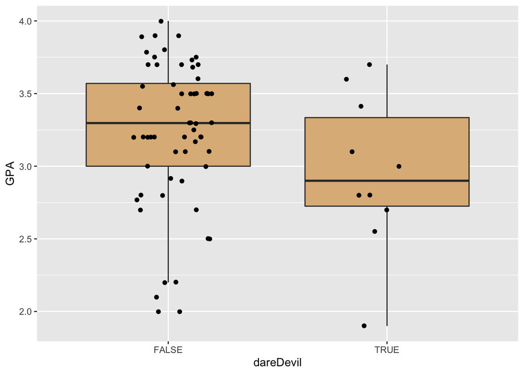

```r
# You can double dip mutations within one line of code
survey %>%
  mutate(dareDevil = fastest > 125,
         speedKmHR = fastest * 1.60934) %>% # made two new variables/columns based on previous data in column 'fastest')
  ggplot(aes(x = dareDevil, y = GPA)) + # plot these new variable values
  geom_boxplot(fill = 'burlywood', outlier.alpha = 0) + # using boxplot to visualize datat
  geom_jitter(width = 0.2) # avoid points overlapping and making them a certain size
```

3. examples of **`group_by()` and `summarise()`** to generate numerical summaries
- *^^ my most used functions in dplyr*

```r
CPS85 %>% # tibble that comes from the `mosaicData`
  group_by(sex) %>% # divide observations based on their values/observations in the variable
  summarize(meanWage = mean(wage)) # make new tibble that has mean wage for each level of sex, you will only have two columns/variables in this tibble 1) sex and 2) meanWage
```

```
## # A tibble: 2 × 2
##   sex   meanWage
##   <fct>    <dbl>
## 1 F         7.88
## 2 M         9.99
```

```r
# create more than 1 summary variable
CPS85 %>%
  group_by(sex) %>%
  summarize(meanWage = mean(wage),
            n = n()) # n() is the count function, very helpful for most summaries ## will count total observations for your variable meanWage
```

```
## # A tibble: 2 × 3
##   sex   meanWage     n
##   <fct>    <dbl> <int>
## 1 F         7.88   245
## 2 M         9.99   289
```

**other summaries you can do are:**

- minimum value
- first quartile (q1)
- median
- third quartile (q3)
- max

if you want to run all 5 summaries (which you should), use `fivenum()` function

```r
# summaries for entire tibble (men and women included)
CPS85 %>%
  .$wage %>% # select one column/vector of information you want to summarize
  fivenum() # run all 5 summary statistics
```

```
## [1]  1.00  5.25  7.78 11.25 44.50
```

```r
# summaries broken down for each sex (more appropriate of comparisons!)
CPS85 %>%
  group_by(sex) %>%
  summarise(n = n(), # count observations
            min = fivenum(wage)[1],
            Q1 = fivenum(wage)[2],
            median = fivenum(wage)[3],
            Q3 = fivenum(wage)[4],
            max = fivenum(wage)[5])
```

```
## # A tibble: 2 × 7
##   sex       n   min    Q1 median    Q3   max
##   <fct> <int> <dbl> <dbl>  <dbl> <dbl> <dbl>
## 1 F       245  1.75  4.75   6.8     10  44.5
## 2 M       289  1     6      8.93    13  26.3
```

```r
# you can also compare multiple variables by group
CPS85 %>%
  group_by(sector, sex) %>%  # looking at SEX and SECTOR
  summarise(n = n(),
            min = fivenum(wage)[1],
            Q1 = fivenum(wage)[2],
            median = fivenum(wage)[3],
            Q3 = fivenum(wage)[4],
            max = fivenum(wage)[5])
```

```
## # A tibble: 15 × 8
## # Groups:   sector [8]
##    sector   sex       n   min    Q1 median    Q3   max
##    <fct>    <fct> <int> <dbl> <dbl>  <dbl> <dbl> <dbl>
##  1 clerical F        76  3     5.1    7     9.55 15.0
##  2 clerical M        21  3.35  6      7.69  9    12
##  3 const    M        20  3.75  7.15   9.75 11.8  15
##  4 manag    F        21  3.64  6.88  10    11.2  44.5
##  5 manag    M        34  1     8.8   14.0  18.2  26.3
##  6 manuf    F        24  3     4.36   4.9   6.05 18.5
##  7 manuf    M        44  3.35  6.58   8.94 11.2  22.2
##  8 other    F         6  3.75  4      5.62  6.88  8.93
##  9 other    M        62  2.85  5.25   7.5  11.2  26
## 10 prof     F        52  4.35  7.02  10    12.3  25.0
## 11 prof     M        53  5     8     12    16.4  25.0
## 12 sales    F        17  3.35  3.8    4.55  5.65 14.3
## 13 sales    M        21  3.5   5.56   9.42 12.5  20.0
## 14 service  F        49  1.75  3.75   5     8    13.1
## 15 service  M        34  2.01  4.15   5.89  8.75 25
```

# More practice!

```r
data("flights", package = "nycflights13")
```

**filter out NA cases**

- Want to correctly count number of flights that left airport

```r
flights %>%
  filter(!is.na(dep_delay)) %>%
  group_by(origin) %>%
  summarise(departures = n(),
            meanDelay = mean(dep_delay))
```

```
## # A tibble: 3 × 3
##   origin departures meanDelay
##   <chr>       <int>     <dbl>
## 1 EWR        117596      15.1
## 2 JFK        109416      12.1
## 3 LGA        101509      10.3
```

**filter for a specific date**

- Find flights that occurred on June 26

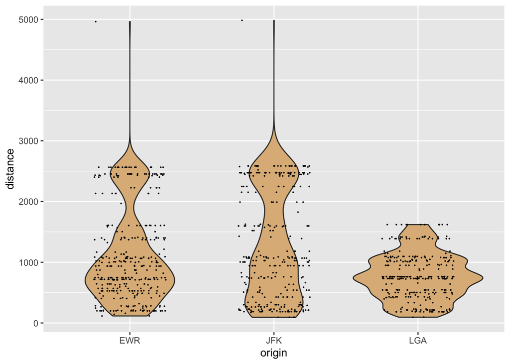

```r
flights %>%
  filter(month == 6 & day == 26) %>%
  ggplot(aes(x = origin, y = distance)) +
    geom_violin(fill = "burlywood") +
    geom_jitter(width = 0.25, size = 0.1)
```

**filter for specific date, variable value and types of variables**

- Find flights that occurred on June 26 that were over 4000 mi and chose only relevant information of origin, destination, and distance

```r
flights %>%
  filter(month == 6 & day == 26 & distance > 4000) %>%
  select(origin, dest, distance)
```

```
## # A tibble: 2 × 3
##   origin dest  distance
##   <chr>  <chr>    <dbl>
## 1 JFK    HNL       4983
## 2 EWR    HNL       4963
```